# San Diego’s Traffic Stop Analysis

Khanh Ngo, Andrew Koken, Hsiang-Hung, Matthew Powell

## Introduction

Racial profiling is a major social problem. On May 25th, many Americans’ attention was focused on the murder of George Floyd, who died while being restrained by a police officer. Floyd’s death has led to the “defund the police” movement by protesters and activists across the country.

In this project, we focus on racial profiling in terms of traffic stops, which is one of the most common interactions between the police and the public [2].

It is statistically proven that African American, Hispanic and Latino American drivers, compared to white drivers, experience a disproportionate number of police stops [1]. Nevertheless, these data have to be carefully examined to conclude that racial profiling occurs in policing. Hence, for this project, the police traffic stops by driver races will undergo several tests, in order to determine whether racial bias might come into play in stop decisions.

Accessing the racial bias in police stop decisions only gives a partial picture of what is going on right now in police practices. However, it could suggest many signs of a broader problem between the police and the people of color community.

## Methods

We used the following libraries.

```r
# tidyverse
library(tidyverse)
```

```r
# ggplot2
library(ggplot2)
# lubridate
library(lubridate)
# suncalc
library(suncalc)
```

The data set for our analysis were retrieved from The Stanford Open Policing Project [2]. We analyzed traffic stops data from San Diego, CA from December 2013 to March 2017.

```r
stops = read_rds("~/my-portfolio/san-diego-traffic-stop/yg821jf8611_ca_san_diego_2020_04_01.rds")
```

Since the chosen data set only include three months of 2017, we will filtered out stops in that year.

```r
stops <- filter(stops, year(date) < 2017)
```

Data where subject race is not applicable will also be removed.

```r
stops <- filter(stops, subject_race != "NA")
```

First, we conducted a brief analysis to quantify the by-race stop counts.We also examined the time regression of the by-race stop counts during 2014 to 2016 to see if there is any difference in trends between races.

In addition, a benchmark test was performed to access the by-race stop rates based on San Diego by-race population. Additional demographic data used are shown below [3].

```r
population <- tibble(
  subject_race = c(
    "asian/pacific islander", "black", "hispanic", "other", "white"
  ),
  num_people = c(213915, 86409, 374605, 234623, 766663)
) %>%
  mutate(subject_race = as.factor(subject_race))
```

After that, an outcome test was conducted to access search outcomes. A successful search is one which uncovers contraband. Thus, we want to find the contraband recovery rate, or hit rate for each race.

Lastly, the veil of darkness test was carried out. According to the veil of darkness hypothesis, during the night, police officers have greater difficulty observing the race of the drivers, hence, racial profiling is less likely to happen. For this test, we compared the race distribution of drivers stopped during daylight to the race distribution of drivers stopped after dark to see whether there is a significant difference. Since sunset times vary based on time of the year and regions, we used the following geographic coordinates for San Diego [4].

```r
center_lat <-32.7157
center_lng <- 117.1611
```

## Results

The number of stops as a function of subject race are given by the following table:

```r
# subject_race table
stops %>%
  count(subject_race)
```

```
## # A tibble: 5 × 2
##   subject_race                n
##   <fct>                   <int>
## 1 asian/pacific islander  30401
## 2 black                   39421
## 3 hispanic               108039
## 4 white                  150846
## 5 other                   24920
```

The number of stops vs. year, separated by race are given by the following graph:

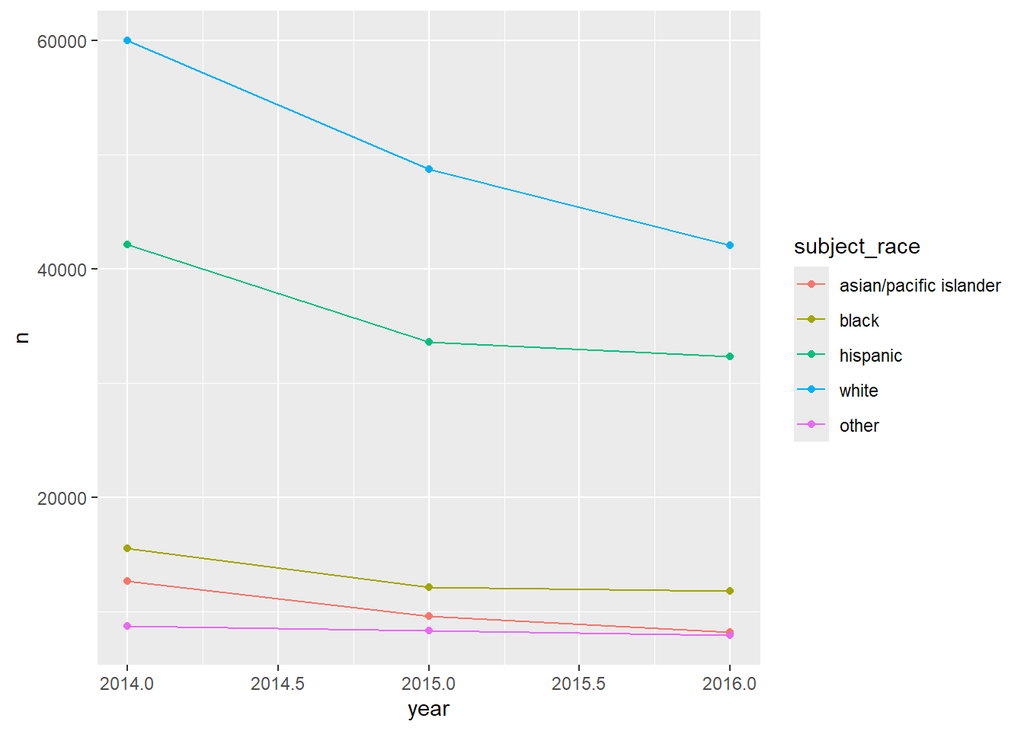

```r
# graph of traffic stops over time for each race
stops %>%
  count(year = year(date), subject_race) %>%
  ggplot(aes(x = year, y = n, color = subject_race)) +
  geom_point() +
  geom_line()
```

From our initial table and graph we did not see any particular outliers that prompted analysis. Thus, we moved on to some benchmarking.

##Benchmark Test

Now we begin a benchmarking test. Here we make sure we are limiting ourselves to vehicular stops.

```r
stops = stops %>% filter(type == "vehicular")
```

After filtering out non-vehicular stops, we also add location data which we will require later. Before we were looking at just the number of stops for each racial category, but now using our stop data we want to calculate the actual proportions of stops for each race. This proportion wil not immediately give us anything useful, as it will be skewed by the population. That will be fixed in the next section of code.

```r
population %>%
  mutate(proportion = num_people / sum(num_people))
```

```
## # A tibble: 5 × 3
##   subject_race           num_people proportion
##   <fct>                       <dbl>      <dbl>
## 1 asian/pacific islander     213915     0.128
## 2 black                       86409     0.0516
## 3 hispanic                   374605     0.223
## 4 other                      234623     0.140
## 5 white                      766663     0.457
```

Here we are determining the stop rate of each racial category and plotting it on a table. The stop rate is our proportion of stops combined with our population data, to give an actual relative amount of stops.

```r
# benchmark test
stops %>%
  count(subject_race) %>%
  # combining 2 tables, subject_race & population
  left_join(
    population,
    by = "subject_race"
  ) %>%
  # add stop rate column
  mutate(stop_rate = n / num_people) # calculate stop rates
```

```
## # A tibble: 5 × 4
##   subject_race                n num_people stop_rate
##   <fct>                   <int>      <dbl>     <dbl>
## 1 asian/pacific islander  30401     213915     0.142
## 2 black                   39421      86409     0.456
## 3 hispanic               108039     374605     0.288
## 4 white                  150846     766663     0.197
## 5 other                   24920     234623     0.106
```

```r
stops %>% group_by(subject_race) %>% summarise(arrest_rate = mean(arrest_made))
```

```
## # A tibble: 5 × 2
##   subject_race           arrest_rate
##   <fct>                        <dbl>
## 1 asian/pacific islander          NA
## 2 black                           NA
## 3 hispanic                        NA
## 4 white                           NA
## 5 other                           NA
```

```r
# stops = stops %>% na.exclude(search_conducted)
# stops = stops %>% na.exclude(search_person)
stops %>%
  group_by(subject_race) %>%
  summarise(
#    search_rate = mean(search_conducted, na.rm = T), #was frisk originally does not work for this analysis
    person_searched_rate = mean(search_person, na.rm = T)
  )
```

```
## # A tibble: 5 × 2
##   subject_race           person_searched_rate
##   <fct>                                 <dbl>
## 1 asian/pacific islander              0.0146
## 2 black                               0.0478
## 3 hispanic                            0.0233
## 4 white                               0.0122
## 5 other                               0.00612
```

##Outcome Test

Here we then check to see how many of these searched people actually had something to be found from a search.

```r
stops %>%
  filter(search_conducted) %>%
  group_by(subject_race) %>%
  summarize(
    hit_rate = mean(contraband_found, na.rm = T)
  )
```

```
## # A tibble: 5 × 2
##   subject_race           hit_rate
##   <fct>                     <dbl>
## 1 asian/pacific islander   0.0998
## 2 black                    0.0899
## 3 hispanic                 0.0809
## 4 white                    0.120
## 5 other                    0.0969
```

As we can see there is no noticeable change in hit rate between races that would justify different searches. From this, no bias seems to be apparent, but there is more than can be done first. Using our location data, we can see if there are any differences when the driver’s race might be more concealed, such as when it is dark out. This is called a veil of darkness test.

##Veil of Darkness Test

In order to conduct this test, we need figure out at what times it is dark and bright enough for the driver to be obscured. These times also vary by time of year, which also must be taken into account. These next two sections set this up and create a table of times to separate whether it is dark or not.

```r
#THis is using the lat and long set earlier.

tz <- lutz::tz_lookup_coords(center_lat, center_lng, warn = F)

# Helper function
time_to_minute <- function(time) {
  hour(hms(time)) * 60 + minute(hms(time))
}

# Compute sunset time for each date in our dataset
sunset_times <-
  stops %>%
  mutate(
    lat = center_lat,
    lon = center_lng
  ) %>%
  select(date, lat, lon) %>%
  distinct() %>%
  getSunlightTimes(
    data = .,
    keep = c("sunset", "dusk"),
    tz = tz
  ) %>%
  mutate_at(vars("sunset", "dusk"), ~format(., "%H:%M:%S")) %>%
  mutate(
    sunset_minute = time_to_minute(sunset),
    dusk_minute = time_to_minute(dusk),
    date = ymd(str_sub(date, 1, 10))
  ) %>%
  select(date, sunset, dusk, ends_with("minute"))
```

```r
sunset_times %>%
  filter(dusk == min(dusk) | dusk == max(dusk))
```

```
##          date   sunset     dusk sunset_minute dusk_minute
## 1  2014-06-29 19:24:28 19:53:00          1164        1193
## 2  2014-06-30 19:24:28 19:53:00          1164        1193
## 3  2014-12-03 17:06:35 17:33:30          1026        1053
## 4  2014-12-04 17:06:32 17:33:30          1026        1053
## 5  2015-06-29 19:24:27 19:53:00          1164        1193
## 6  2015-06-30 19:24:28 19:53:00          1164        1193
## 7  2015-12-03 17:06:35 17:33:30          1026        1053
## 8  2015-12-04 17:06:33 17:33:30          1026        1053
## 9  2016-06-28 19:24:27 19:53:00          1164        1193
## 10 2016-06-29 19:24:28 19:53:00          1164        1193
## 11 2016-12-03 17:06:33 17:33:30          1026        1053
## 12 2016-12-04 17:06:32 17:33:30          1026        1053
```

In order to simplify things we are going to limit our number of stops. In this case we are just going to compare black and white driver stops, as well as filter out any ambiguously dark time periods. This will give us a cleaner view on the probability that the driver is black.

```r
vod_stops <-
  stops %>%
  left_join(
    sunset_times,
    by = "date"
  ) %>%
  mutate(
    minute = time_to_minute(time),
    minutes_after_dark = minute - dusk_minute,
    is_dark = minute > dusk_minute,
    min_dusk_minute = min(dusk_minute),
    max_dusk_minute = max(dusk_minute),
    is_black = subject_race == "black"
  ) %>%
  filter(
    # Filter to get only the intertwilight period
    minute >= min_dusk_minute,
    minute <= max_dusk_minute,
    # Remove ambigous period between sunset and dusk
    !(minute > sunset_minute & minute < dusk_minute),
    # Compare only white and black drivers
    subject_race %in% c("black", "white")
  )


vod_stops %>% nrow()
```

```
## [1] 13697
```

Now that we have everything set up, we can simply check to see whether the proportion of black drivers is noticeably different between times when it is dark and bright.

```r
suppressWarnings(
vod_stops %>%
  filter(time > hm("18:30"), time < hm("18:45")) %>%
  group_by(is_dark) %>%
  summarize(prop_black = mean(is_black)))
```

```
## # A tibble: 2 × 2
##   is_dark prop_black
##   <lgl>        <dbl>
## 1 FALSE        0.215
## 2 TRUE         0.250
```

```r
mod1 <- glm(
  is_black ~ is_dark + splines::ns(minute, df = 6),
  family = binomial,
  data = vod_stops
)

summary(mod1)$coefficients["is_darkTRUE", c("Estimate", "Std. Error")]
```

```
##   Estimate Std. Error
## 0.07770345 0.04935029
```

Unfortunately we don’t have district data so we cannot go any further than that.

## Discussion

During 2014 to 2016, there is a common decreasing trend in traffic stops among all races. However, the overall ranking was not changed.

Black people, who only made up 5% of San Diego’s population, have the highest tendency to be stopped by the police. Based on our analysis, approximate one out of two black drivers will get pulled over by the police, that is significantly higher than any other races’ stop rates.

In addition, from the outcome test, We see that hit rates are slightly lower for black and Hispanic drivers than for white drivers. However, this does not tell whether racial bias might come into play here since successful search is not equivalent to successful stop. Therefore, other possible interference should be considered in the future analysis.

It also would have been helpful to see if the proportions of stops changed in different districts of San Diego, however district data was not recorded so that was not possible.

Overall we believe that the data indicates that a bias in traffic stops does exist against black people in San Diego. The proportion of stops was so high that even with the uncertain outcome of the veil of darkness test that unless district data could paint a different picture, the difference cannot be ignored.

## References

[1] C. R. Epp, S. Maynard-Moody, and D. P. Haider-Markel, Pulled over: how police stops define race and citizenship. Chicago: The University of Chicago Press, 2014.

[2] E. Pierson, C. Simoiu, J. Overgoor, S. Corbett-Davies, D. Jenson, A. Shoemaker, V. Ramachandran, P. Barghouty, C. Phillips, R. Shroff, and S. Goel. “A large-scale analysis of racial disparities in police stops across the United States”. Nature Human Behaviour, Vol. 4, 2020.

[3] “Population,” The City of San Diego. [Online]. Available: https://www.sandiego.gov/economic-development/sandiego/population.

[4] “San Diego, CA, USA,” Lat Long Finder. [Online]. Available: https://www.latlong.net/place/san-diego-ca-usa-7073.html.